# Phylogenetic Analysis of Salamander Genome Size

Clay Cressler

2/16/2023

This markdown script contains all of the code necessary to replicate the phylogenetic comparative analyses of salamander genome size found in the manuscript, “Mueller et al. Metamorphosis imposes variable constraints on genome expansion.”

I will proceed with fitting the following models: a standard Brownian motion model (BM1), a Brownian motion model where the drift parameter ($\sigma$) varies across regimes (BMS), an Ornstein-Uhlenbeck (OU) model where only $\theta$ varies across regimes (OUM), an OU model where selection strength varies across regimes ($\alpha$) (OUMA), an OU model where drift varies across regimes (OUMV), and an OU model where both selection and drift vary across regimes (OUMVA).

It is clear from the table below summarizing the model fits that the multiple-$\alpha$ models (OUMA and OUMVA) produce fitting errors. This can be seen in the log-likelihoods, which if believed are often several orders of magnitude better than simpler models, and from the parameter estimates, which often include at least one parameter that is estimated to be approximately 0. The only model where neither of these seeming errors was OUMA for the simplest adaptive hypothesis (meta.other), which is perhaps unsurprising because that was one of the only models where OUwie did not warn about not having enough data to fit the model. Because almost all of the multiple-$\alpha$ models produced fitting errors, we have decided to discard all of them and focus only Brownian motion models (BM1 and BMS); single-$\alpha$, single-$\sigma$ models (OUM); and single-$\alpha$, multiple-$\sigma$ models (OUMV).

```
##                      Hypothesis  loglik npars    AICc                     alpha
## 1   abrupt.gradual.dd.paed.OUMA 4360.00     9 -8710.0 0.000605, 53.7, 100, 92.9
## 2             meta.dd.paed.OUMA 3890.00     7 -7760.0           37.1, 100, 87.4
## 3     abrupt.gradual.other.OUMA 2820.00     7 -5620.0        38, 9.81, 3.86e-05
## 4    abrupt.gradual.other.OUMVA 2220.00     9 -4420.0          42.7, 39.2, 17.9
## 5  abrupt.gradual.dd.paed.OUMVA 1850.00    12 -3680.0    2.54, 42.1, 43.9, 1.02
## 6               meta.other.OUMA   -7.87     5    26.3               0.239, 1.21
## 8              meta.other.OUMVA   -7.51     6    27.8            1.01e-09, 1.38
## 10           meta.dd.paed.OUMVA   -5.04     9    29.7     1.94, 1.09e-09, 0.348
##                         sigma                       theta
## 1                    3.16e-05 2.21e-36, 0, 2.44e-16, 3.28
## 2                     3.2e-05    2.13e-28, 2.77, 1.32e-26
## 3                    0.000125    3.28, 1.18e-08, 5.11e-15
## 4   0.642, 3.18e-05, 3.37e-05          3.7, -0.761, -17.7
## 5  2.13, 1.57, 3.46e-05, 6.73    0.0104, 3.39, 126, -1490
## 6                       0.455                  3.62, 4.19
## 8                0.459, 0.356                  3.67, 4.12
## 10        0.266, 0.455, 0.281            3.75, 3.58, 5.64
```

Of these, the best-fitting model is the OU model with 4 selective regimes, with separate drift parameters for each regime. Here are the negative log-likelihoods, number of parameters, AICc values, and parameter estimates for each of the models.

```
##                     Hypothesis loglik npars AICc alpha
## 7  abrupt.gradual.dd.paed.OUMV  -3.43     9  0.0  1.29
## 9    abrupt.gradual.other.OUMV  -6.94     7  2.4  1.64
## 11           meta.dd.paed.OUMV  -7.40     7  3.3 0.946
## 12             meta.other.OUMV -10.30     5  4.5  1.22
## 13            meta.dd.paed.BMS -11.90     4  5.6    NA
## 14    abrupt.gradual.other.OUM -11.60     5  7.3  2.07
## 15  abrupt.gradual.dd.paed.OUM -10.70     6  7.6  2.46
## 16  abrupt.gradual.dd.paed.BMS -11.90     5  7.7    NA
## 17              meta.other.OUM -13.00     4  7.8  1.86
## 18              meta.other.BMS -14.10     3  7.9    NA
## 19            meta.dd.paed.OUM -12.50     5  9.1  2.14
## 20    abrupt.gradual.other.BMS -13.90     4  9.6    NA
## 21                         BM1 -19.10     2 15.8    NA
##                         sigma                                       theta
## 7    0.842, 0.374, 0.6, 0.364                       3.73, 2.69, 3.66, 4.3
## 9         0.389, 0.634, 0.835                            2.98, 3.64, 4.05
## 11         0.826, 0.521, 0.37                             4.3, 3.55, 4.62
## 12                0.547, 0.81                                  3.56, 4.37
## 13        0.783, 0.474, 0.349          3.82, 5.52e-12, 2.36e-10, 1.41e-10
## 14                      0.792                            3.01, 3.63, 4.04
## 15                      0.812                      3.76, 2.99, 3.62, 4.18
## 16 0.783, 0.447, 0.484, 0.359 3.82, 5.78e-12, 1.1e-11, 2.27e-10, 1.38e-10
## 17                      0.786                                  3.53, 4.18
## 18               0.458, 0.759                     3.7, 3.14e-10, 5.65e-11
## 19                      0.803                            3.93, 3.51, 4.26
## 20        0.399, 0.485, 0.762          3.69, 2.65e-11, 2.85e-10, 5.82e-11
## 21                      0.683                              3.77, 3.77e-10
```

One way to help visualize what this best-fitting model is telling us is by looking at the distribution of genome sizes for species in each selective regime, relative to the expected stationary distribution of genome sizes, given the model estimates for $\theta$, $\alpha$, and $\sigma$. In particular, Ho and Ane (2013) showed that the stationary distribution of an OU process will be a normal distribution with mean $\theta$ and variance $\sigma^2/(2\alpha)$. From this figure, it is clear that genome size is under strong stabilizing selection in the direct development regime (which is by far the most common selective regime across the tree). This also appears to be true of genome size in salamander that undergo gradual metamorphosis (although since the peak of the genome size distribution is slightly smaller than the predicted mean, there are still some salamanders potentially experiencing some directional selection towards increasing genome sizes). Genome size in salamanders that undero abrupt metamorphosis, on the other hand, appears to be under directional selection towards smaller genome sizes, since almost all the salamanders in this regime have genome sizes that are larger than the expected mean. Conversely, genome size in the paedomorph regime appears to be under directional selection towards larger size (which we know is not actually directional selection so much as unconstrained TE accumulation).

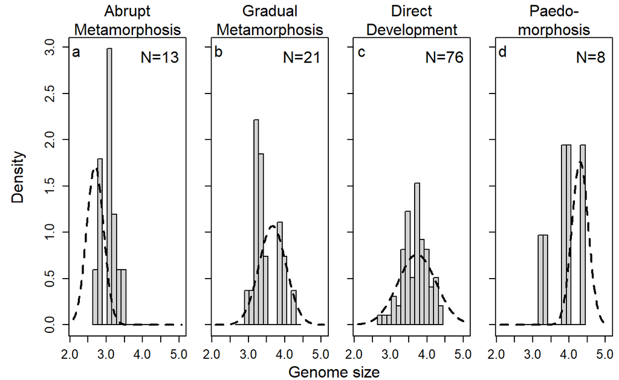

Figure 1: Observed distributions of genome size in each selective regime compared against the stationary distribution predicted by the OUMV model (dashed line).

```
##                    Deterministic pull Stochastic drift
## direct development          0.0696013        0.8421015
## meta-abrupt                -0.4798658        0.3739580
## meta-gradual                0.2592405        0.6003767
## paedomorphosis              0.5293197        0.3637319
```

However, it is important to assess how strong the support for this hypothesis truly is. Following the protocol of Boettiger et al. (2012) for phylogenetic Monte Carlo, I need to simulate datasets under different models and ask how often the true (data-generating) model is rejected in favor of an alternative model.

We will do the following pairwise comparisons of models:

1. $metamorphosis-other$ (OUMV) versus $BM$.
2. $meta-paed-dd$ (OUMV) versus $metamorphosis-other$ (OUMV).
3. $meta_{abrupt}-meta_{gradual}-other$ (OUMV) versus $metamorphosis-other$ (OUMV).
4. $meta_{abrupt}-meta_{gradual}-paed-dd$ (OUMV) versus $meta-paed-dd$ (OUMV).
5. $meta_{abrupt}-meta_{gradual}-paed-dd$ (OUMV) versus $meta_{abrupt}-meta_{gradual}-other$ (OUMV).
6. $meta_{abrupt}-meta_{gradual}-paed-dd$ (OUMV) versus $meta_{abrupt}-meta_{gradual}-paed-dd$ (OUM)

Comparison (1) tests whether we can confidently reject a non-adaptive hypothesis for genome size evolution. Comparisons (2) and (5) test whether distinguishing direct development and paedomorphosis is supported. Comparisons (3) and (4) test whether distinguishing gradual and abrupt metamorphosis is supported. Comparison (6) tests whether allowing separate drift parameters for each regime is supported. We will simulate datasets under all of the models above, and then fit data generated by each of the two models under comparison to each of those models.

We can also use these fits to look at the confidence intervals for each of the parameters of the best-fitting model using a parametric bootstrap.

```
##                 parameter Estimate           CI
## 1                   alpha    1.290  0.403, 3.93
## 2           sigma.sq (dd)    0.842   0.73, 1.08
## 3  sigma.sq (meta-abrupt)    0.374 0.214, 0.521
## 4 sigma.sq (meta-gradual)    0.600 0.399, 0.895
## 5         sigma.sq (paed)    0.364 0.136, 0.629
## 6              theta (dd)    3.730    2.93,4.63
## 7     theta (meta-abrupt)    2.690    1.07,3.44
## 8    theta (meta-gradual)    3.660    3.39,3.93
## 9            theta (paed)    4.300    3.87,5.19
```

```
## [1] 0
```

```
## [1] 0.968
```

```
## [1] 0.118
```

```
## [1] 0.564
```

```
## [1] 0.066
```

```
## [1] 0.622
```

```
## [1] 0.04
```

```
## [1] 0.704
```

```
## [1] 0.064
```

```
## [1] 0.684
```

```
## [1] 0.006
```

```
## [1] 0.984
```

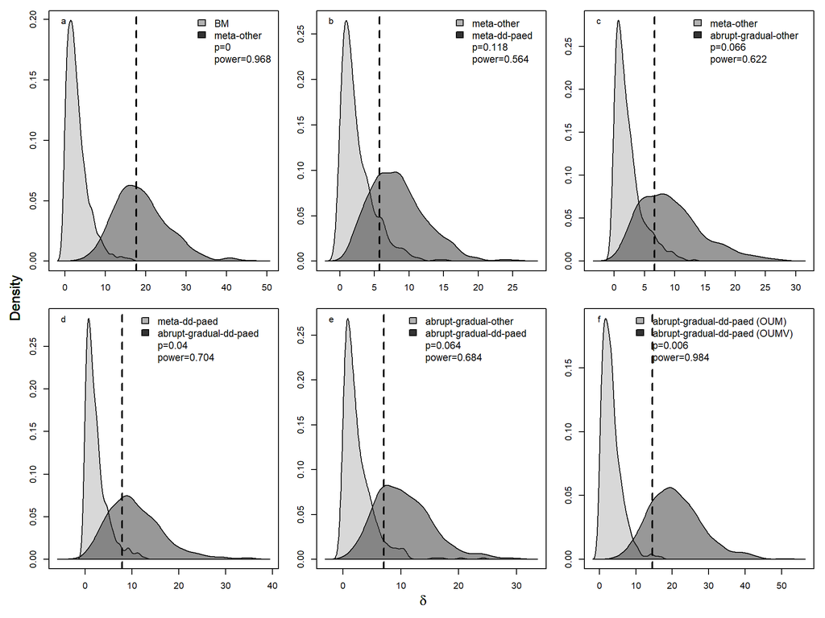

Figure 2: Comparing the distributions of the test statistic when the data is generated by simpler (light gray) or more complex (dark gray) evolutionary models. The dashed line gives the actual value of the test statistic for the true data.

**Analyses with a different evolutionary history for plethodontids**

In the above analyses, the ancestor of all plethodontids is assumed to be a metamorphosing amphibian. However, there is some debate about this, and some researchers think that this ancestor was actually a direct developer. As such, we want to make sure that the conlusions drawn above are unaffected by this assumption. This requires modifying all of the adaptive hypotheses to “repaint” the ancestral nodes that are currently coded as metamorphosis.

As with the original evolutionary history, the OU models with variable $\alpha$ produced nonsensical fitting results.

```
##                      Hypothesis  loglik    AICc                       alpha
## 1              meta.other.OUMVA 4720.00 -9420.0               100, 7.63e-05
## 2             meta.dd.paed.OUMA 3460.00 -6910.0         18.2, 100, 6.06e-09
## 3            meta.dd.paed.OUMVA 3470.00 -6910.0            18.2, 99.9, 37.5
## 4               meta.other.OUMA 3450.00 -6890.0                    99.9, 18
## 5   abrupt.gradual.dd.paed.OUMA   -3.36    26.4     2.39, 1.02, 0.74, 0.641
## 7     abrupt.gradual.other.OUMA   -6.94    28.9          0.609, 0.428, 1.91
## 8    abrupt.gradual.other.OUMVA   -5.24    30.1           3.89, 0.178, 2.21
## 10 abrupt.gradual.dd.paed.OUMVA   -1.65    30.3 3.72, 5.43e-06, 0.777, 1.09
##                          sigma                      theta
## 1           6.95e-05, 3.66e-05             3.28, 1.37e-26
## 2                      3.2e-05  2.48e-14, 3.17, -1.11e-34
## 3  3.61e-05, 3.2e-05, 3.16e-05  -5.07e-20, 3.27, 3.44e-12
## 4                     3.17e-05             3.24, 7.94e-19
## 5                        0.491      3.61, 1.69, 3.68, 4.7
## 7                        0.499           1.84, 3.69, 3.95
## 8         0.0691, 0.503, 0.414           3.28, 3.72, 3.95
## 10   0.324, 1.36, 0.553, 0.334 3.63, -1290000, 3.68, 4.34
```

Excluding these poor-fitting models, the top model remains unchanged from the previous analysis: $meta_{abrupt}-meta_{gradual}-dd-paed$ is still the best-fitting hypothesis. There is some reordering of the other models, however, in that the multiple-$\sigma$ stochastic models (BMS) outperform some of the multiple-$\sigma$ adaptive models. However, none of these stochastic, Brownian motion models outperform their adaptive, OU models (e.g., every OUMV model outperforms the corresponding BMS model). Thus, our overall evolutionary conclusions remain unchanged by modifying the selective regime history of plethodontid salamanders.

```
##                     Hypothesis loglik AICc alpha                      sigma
## 6  abrupt.gradual.dd.paed.OUMV  -4.16 28.0  1.35 0.842, 0.382, 0.608, 0.375
## 9            meta.dd.paed.OUMV  -7.61 30.2 0.888         0.83, 0.507, 0.354
## 11            meta.dd.paed.BMS -11.00 30.4    NA        0.791, 0.458, 0.299
## 12   abrupt.gradual.other.OUMV  -8.00 31.0  1.59        0.388, 0.632, 0.836
## 13  abrupt.gradual.dd.paed.BMS -10.60 31.7    NA 0.796, 0.376, 0.491, 0.298
## 14             meta.other.OUMV -10.80 32.1  1.16               0.534, 0.814
## 15  abrupt.gradual.dd.paed.OUM -10.70 34.2  2.48                      0.814
## 16              meta.other.BMS -14.00 34.3    NA               0.453, 0.758
## 17    abrupt.gradual.other.BMS -13.60 35.6    NA        0.375, 0.484, 0.761
## 18    abrupt.gradual.other.OUM -12.70 36.0  1.95                      0.791
## 19              meta.other.OUM -13.90 36.2  1.75                      0.784
## 20            meta.dd.paed.OUM -13.00 36.5  2.14                      0.806
## 21                         BM1 -19.10 42.3    NA                      0.683
##                                           theta
## 6                        3.54, 2.55, 3.66, 4.29
## 9                                4.2, 3.59, 4.6
## 11            3.86, 4.6e-12, 2.16e-10, 1.65e-10
## 12                                2.94, 3.64, 4
## 13 3.86, 4.15e-12, 1.83e-12, 2.06e-10, 1.74e-10
## 14                                   3.59, 4.31
## 15                       3.62, 2.84, 3.62, 4.18
## 16                      3.73, 3.1e-10, 6.36e-11
## 17           3.73, 6.49e-12, 2.99e-10, 6.79e-11
## 18                             2.93, 3.63, 3.95
## 19                                   3.55, 4.11
## 20                             3.81, 3.52, 4.26
## 21                               3.77, 3.77e-10
```

**Analyses with a different handling of the root state**

OUwie has different options for dealing with the root state, $X(0)$. Absent any information about the phenotype deep in the tree, this parameter is often very difficult to estimate in OU models (Cressler, et al. 2015). One alternative is to assume that the value of $X(0)$ is distributed according to the stationary distribution of an OU process, which eliminates this parameter by absorbing the variance into the covariance matrix implied by the phylogeny itself (Ho and Ané 2013). However, OUwie does not currently support this approach for OU models with multiple $\alpha$ or $\sigma$ parameters, and as far as we know, the mathematical modifications for these models have not been worked out. Because the option to estimate the value of the root node as in the earlier implementations (Hansen 1997; Butler and King 2004; and specified in OUwie by setting root.station=FALSE) is available for all of the models of interest, we used it for all of the model fitting above. Here we explore the implications of that decision for the parameter estimates and model fits. We can only do this, of course, for the single-$\alpha$, single-$\sigma$ models.

The AICc estimates are not dramatically affected by handling of the root state: the order of the best-fitting models is the same in either case. (Note, however, that the best model in the single-$\alpha$, single-$\sigma$ case is not the same as the best model when $\sigma$ is allowed to vary amongst the regimes, and that the AICc differences in model fits are smaller, suggesting that the support for the hypotheses is weaker.)

```
##                        Estimating.root Stationary.root
## abrupt-gradual-other             33.81           34.02
## abrupt-gradual-dd-paed           34.13           34.24
## meta-other                       34.29           34.57
## meta-dd-paed                     35.63           35.82
```

We also see almost no difference in the estimates of the $\theta$ values for each selective regime.

```
##                               Estimating.root     Stationary.root
## meta-other                   3.01, 3.63, 4.04    3.02, 3.62, 4.03
## meta-dd-paed           3.76, 2.99, 3.62, 4.18 3.76, 3, 3.62, 4.18
## abrupt-gradual-other               3.53, 4.18          3.53, 4.16
## abrupt-gradual-dd-paed       3.93, 3.51, 4.26    3.92, 3.51, 4.25
```

We see similar estimates of the strength of the deterministic pull, $\alpha$, although the differences are somewhat larger.

```
##                        Estimating.root Stationary.root
## meta-other                        2.07            2.14
## meta-dd-paed                      2.46            2.52
## abrupt-gradual-other              1.86            1.94
## abrupt-gradual-dd-paed            2.14            2.22
```

Finally, the estimates of noise intensity $\sigma$ are almost identical.

```
##                        Estimating.root Stationary.root
## meta-other                        0.63            0.64
## meta-dd-paed                      0.66            0.67
## abrupt-gradual-other              0.62            0.63
## abrupt-gradual-dd-paed            0.64            0.65
```

This suggests that the handling of the root state does not have a large effect on the parameter estimates or model fits.